# Age Structure Population Modelling

# See notes on population matrix modeling (agestructure.pdf)

# Set up the Leslie Matrix

Leslie Matrix

```r
nclasses = 5

# create a growth matrix to store fertility and survivability information
gmatrix=matrix(nrow=nclasses, ncol=nclasses)
gmatrix
```

```
##      [,1] [,2] [,3] [,4] [,5]
## [1,]   NA   NA   NA   NA   NA
## [2,]   NA   NA   NA   NA   NA
## [3,]   NA   NA   NA   NA   NA
## [4,]   NA   NA   NA   NA   NA
## [5,]   NA   NA   NA   NA   NA
```

```r
# change NAs to zero
gmatrix[]=0.0
gmatrix
```

```
##      [,1] [,2] [,3] [,4] [,5]
## [1,]    0    0    0    0    0
## [2,]    0    0    0    0    0
## [3,]    0    0    0    0    0
## [4,]    0    0    0    0    0
## [5,]    0    0    0    0    0
```

```r
# assign values for fertility for each of the age classes
# notes that fertility rates are births per capita (number in class) per
# time step - time step here is decade - but could be hours
fert =  c(0,0.4,0.3,0.1,0.01)

# enter into our matrix
 gmatrix[1,]=fert

 # now add survivability
 # survivability (to the next class) is also per time step
gmatrix[2,1]=0.5
gmatrix[3,2]=0.8
gmatrix[4,3]=0.2
gmatrix[5,4]=0.1

# we als want to to account for the oldest population group - they don't transfer to another group
# but they do die - this will be survivability per time step but they just stay in their class/group
gmatrix[5,5]=0.1

gmatrix
```

```
##      [,1] [,2] [,3] [,4] [,5]
## [1,]  0.0  0.4  0.3  0.1 0.01
## [2,]  0.5  0.0  0.0  0.0 0.00
## [3,]  0.0  0.8  0.0  0.0 0.00
## [4,]  0.0  0.0  0.2  0.0 0.00
## [5,]  0.0  0.0  0.0  0.1 0.10
```

# Use Leslie matrix to grow the population

```r
# start with an initial population, lets say 1 individual in each class

p0 = rep(1, times=nclasses)

# advance to the next time step
# note the use of matrix multiplication

p1 = gmatrix %*% p0
p1
```

```
##      [,1]
## [1,] 0.81
## [2,] 0.50
## [3,] 0.80
## [4,] 0.20
## [5,] 0.20
```

```r
# has the total number of individuals changed?




sum(p1)
```

```
## [1] 2.51
```

```r
sum(p0)
```

```
## [1] 5
```

```r
# growth rate
sum(p1)/sum(p0)
```

```
## [1] 0.502
```

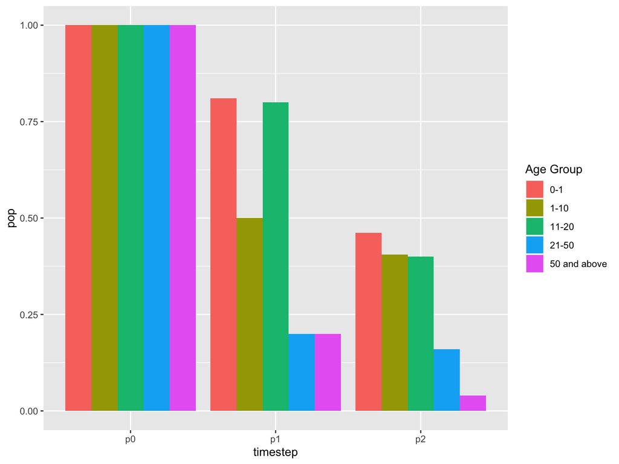

```r
#add another year
p2 = gmatrix %*% p1

# combined
pop = cbind.data.frame(p0,p1,p2)
pop$age = c("0-1","1-10","11-20","21-50","50 and above")

popl = pop %>% pivot_longer(names_to="timestep",values_to="pop",-age)
ggplot(popl, aes(timestep, pop,fill=as.factor(age)))+geom_col(position="dodge")+labs(fill="Age Group")
```

```r
# how might you change parameters to have the population grow?
```

# Multiple Time Steps

use function to evolve a population through time

- inputs = survivability, fertility, initial population, time steps
- output = final population matrix
- a dynamic model - difference equations - similar to our diffusion model

```r
source("../R/evolve_pop.R")

# example evolve China pop
# fertility rates
F1 = 0.0
F2 = 0.25/2
F3 = 0.5/2
F4 = 0.25/2

# survivability - based on mortality rates per thousand per decade
p12 = 1-79/1000
p23 = 1-9.8/1000
p34 = 1-16/1000
p45 = 1-25/1000
p56 = 1-10/1000
p67 = 1-110/1000
p78 = 1-270/1000
p89=1-630/1000
p99 = 0.1

# initial population parameters
ini = c(235,224,182,124,95,69,42,24,6)
ndecades = 15
fert_china = c(0,F2,F3,F4,0,0,0,0,0)
surv_china = c(p12,p23,p34,p45,p56,p67,p78,p89,p99)
china_pop=evolve_pop(fert_china, surv_china, ini, ndecades)

head(china_pop)
```

```
## $popbyage
##       [,1]     [,2]     [,3]      [,4]      [,5]      [,6]      [,7]      [,8]
##  [1,]  235  89.0000 104.8916  91.10660  58.72768  44.38663  39.29873  28.71923
##  [2,]  224 216.4350  81.9690  96.60514  83.90918  54.08820  40.88009  36.19413
##  [3,]  182 221.8048 214.3139  81.16570  95.65841  83.08687  53.55813  40.47946
##  [4,]  124 179.0880 218.2559 210.88491  79.86705  94.12788  81.75748  52.70120
##  [5,]   95 120.9000 174.6108 212.79953 205.61279  77.87038  91.77468  79.71354
##  [6,]   69  94.0500 119.6910 172.86469 210.67153 203.55666  77.09167  90.85693
##  [7,]   42  61.4100  83.7045 106.52499 153.84958 187.49766 181.16543  68.61159
##  [8,]   24  30.6600  44.8293  61.10428  77.76324 112.31019 136.87329 132.25076
##  [9,]    6   9.4800  12.2922  17.81606  24.39019  31.21142  44.67591  55.11071
##           [,9]    [,10]    [,11]    [,12]     [,13]     [,14]     [,15]
##  [1,] 21.23178 17.24513 13.40036 10.04757  7.856124  6.146357  4.698374
##  [2,] 26.45041 19.55447 15.88277 12.34173  9.253814  7.235490  5.660795
##  [3,] 35.83942 26.19120 19.36284 15.72711 12.220780  9.163126  7.164582
##  [4,] 39.83179 35.26599 25.77214 19.05303 15.475481 12.025247  9.016516
##  [5,] 51.38367 38.83600 34.38434 25.12783 18.576706 15.088594 11.724616
##  [6,] 78.91641 50.86983 38.44764 34.04050 24.876555 18.390939 14.937708
##  [7,] 80.86267 70.23560 45.27415 34.21840 30.296045 22.140134 16.367936
##  [8,] 50.08646 59.02975 51.27199 33.05013 24.979429 22.116113 16.162298
##  [9,] 54.44385 23.97638 24.23864 21.39450 14.367999 10.679189  9.250881
##
## $poptot
##  [1]    0.0000 1001.0000 1022.8278 1054.5582 1050.8719  990.4497  888.1359
##  [8]  747.0754  584.6376  439.0465  341.2043  268.0349  205.0008  157.9029
## [15]  122.9852
```

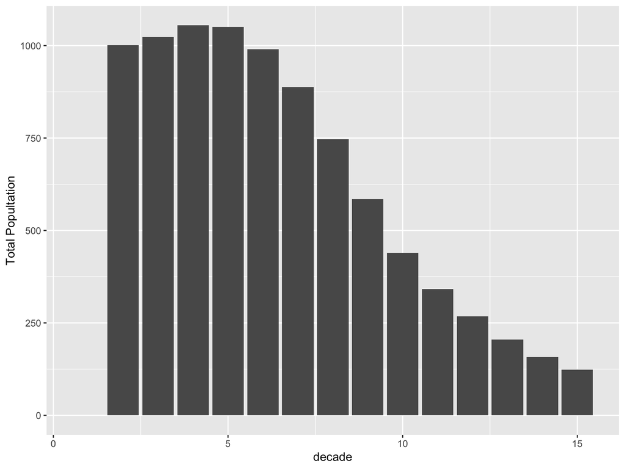

```r
# graph diffeernt components of the output
# total population

# add decade
decade = seq(from=1, to=ndecades)
china_tot = cbind.data.frame(decade=decade, poptot=china_pop$poptot)
ggplot(china_tot, aes(decade, poptot))+geom_col()+labs(y="Total Popultation")
```

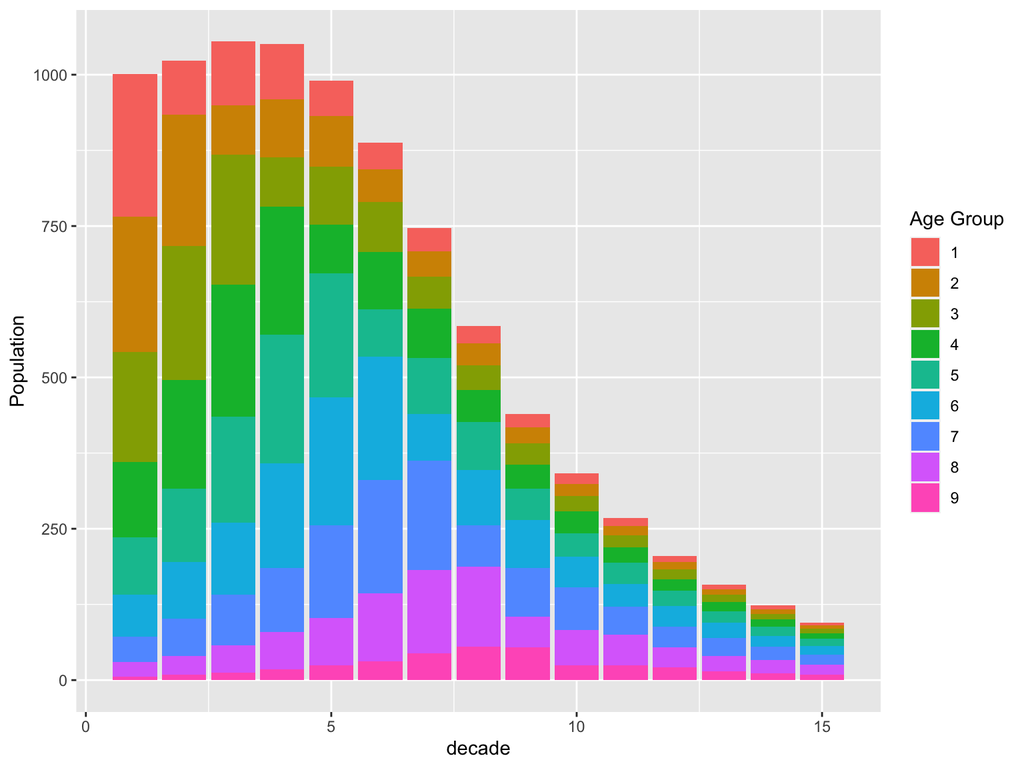

```r
# plot information about ages
china_ages = cbind.data.frame(decade=decade, t(china_pop$popbyage))
china_agesl = china_ages %>% pivot_longer(names_to="agecat", values_to="pop",-decade)
ggplot(china_agesl, aes(decade, pop, fill=agecat))+geom_col()+labs(y="Population", fill="Age Group")
```

# Find parameters that mantain a stable population!

# Microbial Populations - Another example

Lets try with a more complicated example - evolving an age structured population

Sensitivity **To**: fertility and survivability rates

Assume we are looking at microbial population and monthly fertility and mortality rates; but format the same as china example

# Microbial Population Parameters

These microbes live for approximately 2 years they are reproduce after 1 month of maturation

- 3 age groups
- 0-1 months old
- 1-2 months old
- more than 2 months

Try setting this up…

```r
source("../R/evolve_pop.R")


# set up best guess case
# survivability - based on mortality rates per thousand per decade
p12 = 0.9
p23 = 0.7
p34 = 0.2

F1= 0.0
F2 = 2.0
F3 = 0.3

# initial population parameters
ini = c(1000,1000, 1000)
nmonths = 12
fert_micro = c(F1,F2,F3)
surv_micro = c(p12,p23,p34)
micro_pop=evolve_pop(fert_micro, surv_micro, ini, nmonths)

# population after 12 months
micro_pop$poptot[12]
```

```
## [1] 75011.68
```

# Sensitivity Analysis for matrix populations

Now lets use Sobel sensitivity analysis to explore the how our intervention might impact the population…

AND account for uncertainty in some of our parameters

Reminder Sobel sensitivity analysis breaks variance of output into

- variance associated directly with parameter alone (fraction associated with each parameter, sum to 1)
- variance associated with parameter and interaction with other parameters (sum can be more than 1)

# Steps

- run sobel to get parameter sets in a sensitivity analysis object
- run model with those parameter sets
- tell the senstivity object about results associated with each parameter set
- look at sensitivity analysis metric from sobel

```r
library(sensitivity)

# survivability - based on mortality rates per thousand per decade
nsample=200

p12 = 0.9
p23 = 0.7
p34 = 0.2

# create our two samples for Sobel
# first do our survivability
ps1 = cbind.data.frame(p12=runif(min=0.4, max=0.92, n=nsample), p23 = runif(min=0.3, max=0.72, n=nsample),
                       p34 = runif(min=0.05, max=0.22, n=nsample))

ps2 = cbind.data.frame(p12=runif(min=0.4, max=0.92, n=nsample), p23 = runif(min=0.3, max=0.72, n=nsample),
                       p34 = runif(min=0.05, max=0.22, n=nsample))

# now include uncertainty in our Fertility
F1= 0.0
F2 = 2.0
F3 = 0.3

fs1 = cbind.data.frame(f1=rnorm(mean=0, sd=0, n=nsample),
                       f2 = rnorm(mean=2.0, sd=0.1, n=nsample),
                       f3 = rnorm(mean=0.3, sd=0.01, n=nsample))

fs2 = cbind.data.frame(f1=rnorm(mean=0, sd=0, n=nsample),
                       f2 = rnorm(mean=2.0, sd=0.1, n=nsample),
                       f3 = rnorm(mean=0.3, sd=0.01, n=nsample))


# put servivability and fertility together
allp1 = cbind.data.frame(ps1,fs1)
allp2 = cbind.data.frame(ps2,fs2)


# get sobel samples

sens_micro = sobolSalt(model = NULL, allp1, allp2, nboot = 100)

head(sens_micro$X)
```

```
##           [,1]      [,2]       [,3] [,4]     [,5]      [,6]
## [1,] 0.6619691 0.5299277 0.21147295    0 1.812207 0.2966619
## [2,] 0.7522288 0.4293910 0.10977677    0 2.045233 0.2917289
## [3,] 0.4339690 0.4888201 0.07822424    0 1.826275 0.3043628
## [4,] 0.6615481 0.3335129 0.20589713    0 1.856832 0.3093770
## [5,] 0.7272097 0.4347897 0.09725829    0 2.074932 0.3077934
## [6,] 0.4229459 0.5912494 0.10487093    0 2.068719 0.2891540
```

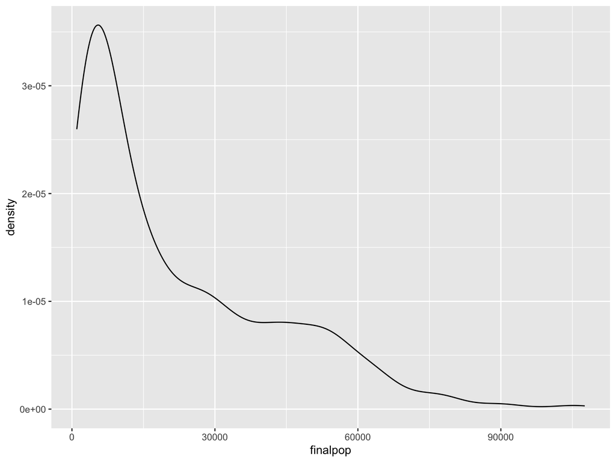

```r
nsim=nrow(sens_micro$X)

# add parameter names
colnames(sens_micro$X)=colnames(allp1)
# run model and save what we care about: final population after 12 months
# this is already output by evolve_pop so we don't need a compute_metric function

ini = c(1000,1000, 1000)
nmonths = 12


# as before combine our application of the the dynamics model - for each
# parameter set, with code to extract our metric of interest (final population)
p_wrapper = function(p12, p23, p34, f1,f2,f3,use_func, initialpop, nstep ) {
fertility=c(f1,f2,f3)
survivability= c(p12,p23,p34)
res = use_func(survivability =survivability, fertility = fertility, initialpop=initialpop, nstep=nstep)
# now return the final population total
return(finalpop=res$poptot[nstep])
}

# use pmap here so we can specify rows of our sensitivity analysis parameter object
res = as.data.frame(sens_micro$X) %>% pmap_dbl(p_wrapper, initialpop=ini, nstep=nmonths, use_func=evolve_pop)

# plot results (variation in final population across all parameter)
# ggplot needs a dataframe - so do a quick conversion with data.frame
ggplot(data.frame(finalpop=res), aes(x=finalpop))+geom_density()
```

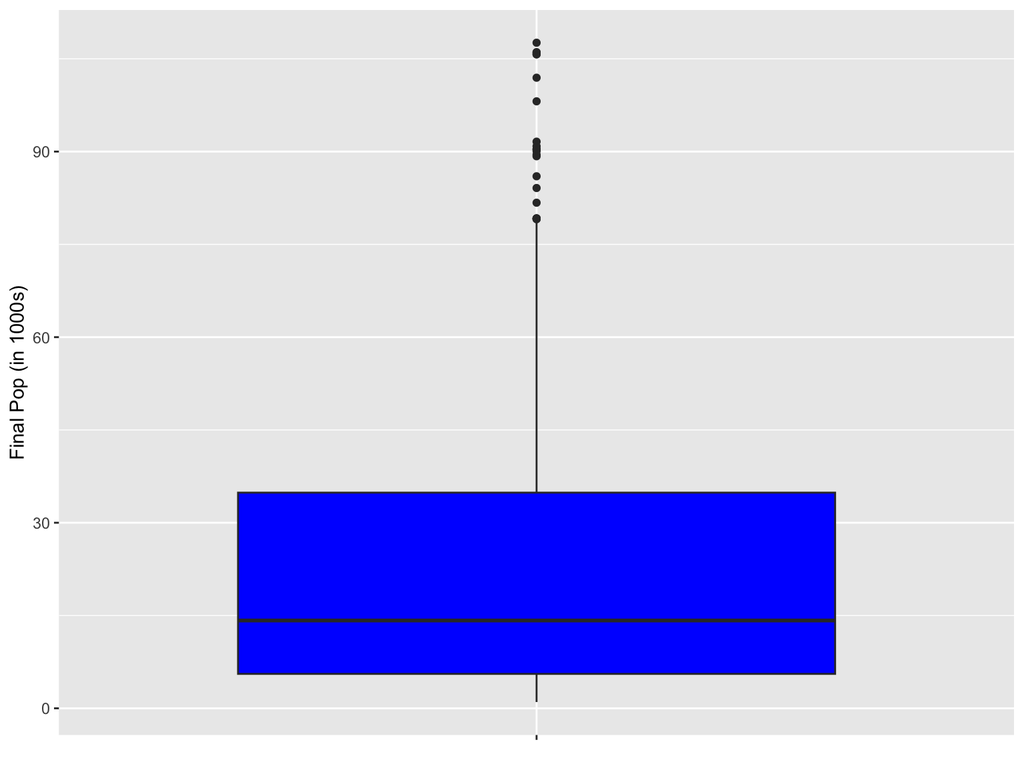

```r
# or a boxplot
ggplot(data.frame(finalpop=res), aes(x="", y=finalpop/1000) )+geom_boxplot(fill="blue")+
  theme(axis.title.x = element_blank())+labs(y="Final Pop (in 1000s)")
```

```r
# give our results to sensitivity structure

sens_micro=tell(sens_micro, res)

# loot at results
sens_micro$S
```

```
##        original          bias std. error  min. c.i. max. c.i.
## X1  0.899384134 -1.813861e-03 0.01712158  0.8672908 0.9361751
## X2 -0.010669784 -4.799236e-03 0.06548412 -0.1598395 0.1216034
## X3 -0.017483423 -4.129586e-03 0.06492902 -0.1546244 0.1195597
## X4 -0.019707130 -4.080539e-03 0.06482044 -0.1566521 0.1150506
## X5 -0.005623582 -9.718252e-05 0.07130170 -0.1692533 0.1471192
## X6 -0.020654761 -3.502830e-03 0.06427006 -0.1558238 0.1125714
```

```r
sens_micro$T
```

```
##         original          bias   std. error     min. c.i.    max. c.i.
## X1  9.828050e-01  1.083812e-02 7.203879e-02  8.400646e-01 1.137671e+00
## X2  1.615703e-02  1.568590e-04 3.062419e-03  9.557464e-03 2.055023e-02
## X3  7.559027e-04  5.243831e-06 1.193127e-04  5.083091e-04 9.579812e-04
## X4 -1.776357e-15  1.169065e-15 1.560584e-15 -5.488176e-15 8.881784e-16
## X5  1.171637e-01 -5.266804e-03 2.140792e-02  7.456440e-02 1.605473e-01
## X6  3.414842e-04  1.063467e-05 4.920300e-05  2.277600e-04 4.311617e-04
```

```r
# make this a bit easier to see
rownames(sens_micro$S) = colnames(sens_micro$X)
sens_micro$S
```

```
##         original          bias std. error  min. c.i. max. c.i.
## p12  0.899384134 -1.813861e-03 0.01712158  0.8672908 0.9361751
## p23 -0.010669784 -4.799236e-03 0.06548412 -0.1598395 0.1216034
## p34 -0.017483423 -4.129586e-03 0.06492902 -0.1546244 0.1195597
## f1  -0.019707130 -4.080539e-03 0.06482044 -0.1566521 0.1150506
## f2  -0.005623582 -9.718252e-05 0.07130170 -0.1692533 0.1471192
## f3  -0.020654761 -3.502830e-03 0.06427006 -0.1558238 0.1125714
```

```r
rownames(sens_micro$T) = colnames(sens_micro$X)
sens_micro$T
```

```
##          original          bias   std. error     min. c.i.    max. c.i.
## p12  9.828050e-01  1.083812e-02 7.203879e-02  8.400646e-01 1.137671e+00
## p23  1.615703e-02  1.568590e-04 3.062419e-03  9.557464e-03 2.055023e-02
## p34  7.559027e-04  5.243831e-06 1.193127e-04  5.083091e-04 9.579812e-04
## f1  -1.776357e-15  1.169065e-15 1.560584e-15 -5.488176e-15 8.881784e-16
## f2   1.171637e-01 -5.266804e-03 2.140792e-02  7.456440e-02 1.605473e-01
## f3   3.414842e-04  1.063467e-05 4.920300e-05  2.277600e-04 4.311617e-04
```

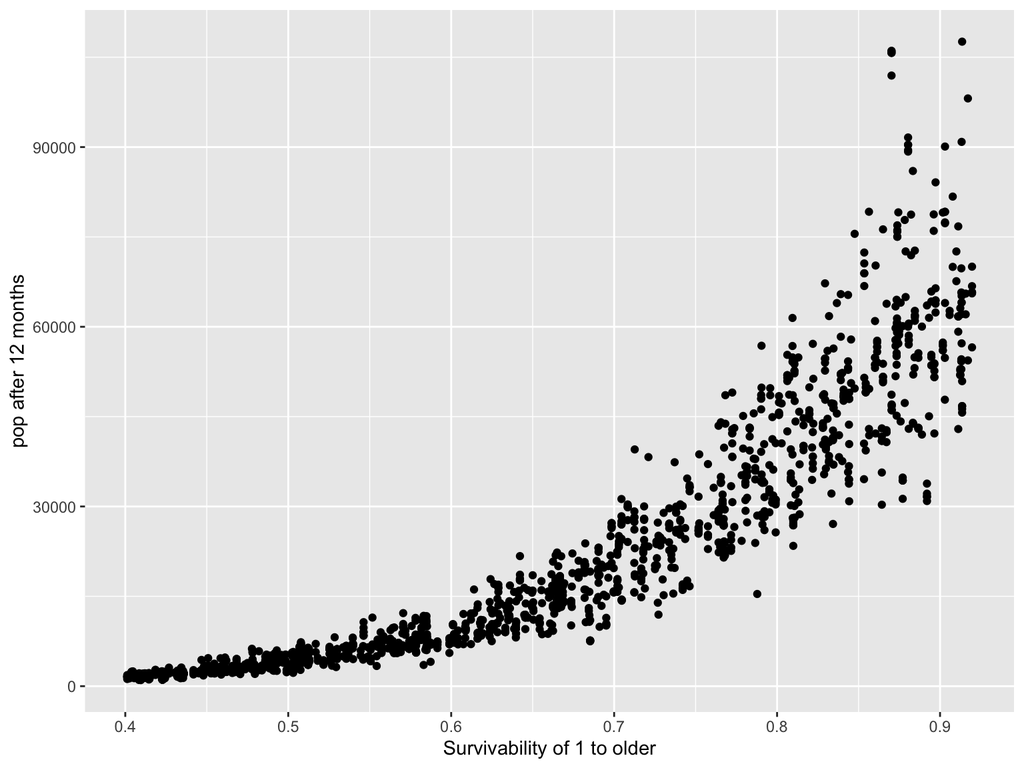

```r
# notice how p12 is by far the most sensitive parameter

# graph the most sensitive parameter
tmp = cbind.data.frame(sens_micro$X, pop12=sens_micro$y)
ggplot(tmp, aes(p12, pop12))+geom_point()+labs(x="Survivability of 1 to older",y="pop after 12 months")
```